# Spatial transcriptomics with Seurat: imaging-based platforms (MERSCOPE, Xenium, CosMx)

Local version, reads from the workshop data repo, no network access

Published

August 5, 2026

Local rework of `seurat5_spatial_vignette_2.html`, the Seurat vignette “Analysis of Image-based Spatial Data in Seurat”.

Upstream source: https://satijalab.org/seurat/articles/seurat5_spatial_vignette_2 (Rmd: `vignettes/seurat5_spatial_vignette_2.Rmd`, Seurat 5.5.0, compiled April 28, 2026).

This vignette covers three imaging-based spatial platforms, each in its own section:

- Vizgen MERSCOPE (MERFISH), mouse brain
- 10x Genomics Xenium In Situ, mouse brain
- Nanostring CosMx Spatial Molecular Imager (SMI), FFPE human lung

**ImportantStatus: transcribed from upstream, first render is a test**

**WarningThese datasets are the main staging burden**

Unlike sequencing-based Visium (one matrix plus one image), imaging platforms ship as **directories of many raw files** (cell x gene matrix, per-transcript molecule coordinates, cell segmentation polygons, centroids, metadata). The loaders `LoadVizgen()`, `LoadXenium()`, and `LoadNanostring()` each expect a specific directory layout. These are large multi-file downloads and are the biggest staging job of the whole workshop. Per-platform expected layouts are stated in callouts in each section below.

## Setup

```r
data_dir <- "~/MEGA/workshop_data/spatial_imaging"
in_data_dir <- function(basename) {
  return(file.path(data_dir, basename))
}
# allen_cortex.rds is shared with the imaging tutorial and staged once at the
# top level of the data dir, so read it from the root rather than data_dir.
data_root <- "~/MEGA/workshop_data"
```

```r
library(Seurat)
library(future)

# The CGU teaching cluster gives each OnDemand RStudio session 4 logical CPUs
# (= 2 physical cores, the nodes are 2 sockets x 10 cores x 2 threads) and a
# 16 GB memory reservation. Match `workers` to physical cores, not threads.
#
# `multisession` workers are separate R processes with no shared memory, so
# `future` serializes every global referenced in a parallel expression and
# ships a full copy to each worker. N workers therefore means N + 1 resident
# copies of the Seurat object. At the upstream vignette's `workers = 10` a
# 1.5 GB object already exceeds 16 GB.
#
# Slurm is not enforcing per-job memory limits on these nodes (no
# /etc/slurm/cgroup.conf on the compute nodes, JobAcctGatherType unset), so
# overshooting is not a clean per-job kill. The node-level OOM killer fires
# and can take out the other students sharing the node.
workers_n <- 2
plan("multisession", workers = workers_n)
library(ggplot2)

# Guardrail, not a cap. This is the size at which `future` refuses to export a
# global and raises an error. Keeping it near the per-worker copy we can afford
# turns "silently make 3 copies and get OOM-killed" into an informative error.
# The upstream vignette's 10 GB silences exactly the warning students need.
#
# 3 GiB rather than the 2 GiB first tried here: `SCTransform()` legitimately
# exports a little over 2 GiB on the smaller objects in this document, so 2 GiB
# tripped on work that is fine. It is still far below the 10 GiB that would let
# the Vizgen object through and OOM a 16 GB machine.
options(future.globals.maxSize = 3 * 1024^3)

#' Run an expression with parallel workers disabled
#'
#' `SCTransform()` ships its whole model-fitting closure to every worker. On the
#' Vizgen object that closure measured 3.02 GiB, so on a 16 GB machine two
#' workers means three resident copies and an OOM kill. Raising
#' `future.globals.maxSize` past that would hide the problem rather than fix it,
#' so the expensive normalizations run sequentially instead. They are not the
#' slow part of this document.
#'
#' @param expr Expression to evaluate with `plan("sequential")`.
#' @return The value of `expr`.
without_workers <- function(expr) {
  old_plan <- plan("sequential")
  on.exit(plan(old_plan), add = TRUE)
  force(expr)
}
```

## Mouse Brain: Vizgen MERSCOPE

This dataset was produced using the Vizgen MERSCOPE system, which uses MERFISH technology. The full public dataset contains nine samples (three full coronal slices of the mouse brain, three biological replicates per slice). The gene panel has 483 targets. Here we analyze one sample, slice 2 replicate 1 (`s2r1`). The median number of transcripts detected per cell is 206.

Upstream, the dataset is read with `LoadVizgen()`, which parses the output of the Vizgen analysis pipeline. The resulting Seurat object holds a count matrix (483 transcripts per cell, stored in the `Vizgen` assay), plus imaging-specific slots for cell centroids, cell segmentation boundaries, and individual molecule positions.

We read a pre-built copy of exactly that object instead, for the reasons in the callout below.

**ImportantWhy this section reads a staged object rather than calling `LoadVizgen()`**

`LoadVizgen()` on this dataset takes about **41 minutes** and peaks near **16 GiB** of memory, almost all of it spent parsing 1242 `HDF5` cell-boundary files one at a time. It also overflows R’s pointer protection stack while assembling the segmentation polygons, and dies with `protect(): protection stack overflow` unless R is started with `--max-ppsize=500000`. That flag can only be set when R starts, so no chunk in this document could fix it.

`slides/wed_afternoon/staging/stage_vizgen_object.R` does that work once and saves the result. Reading it back takes about a minute.

**NoteExpected staged layout: Vizgen MERSCOPE**

This tutorial needs one file, `spatial_imaging/vizgen_mouse_brain_s2r1.rds`.

To rebuild it you need the raw MERSCOPE pipeline outputs, which are gated behind vendor registration, staged at `spatial_imaging/vizgen_mouse_brain/s2r1/`: the cell-by-gene matrix (`cell_by_gene.csv`), cell metadata (`cell_metadata.csv`), the detected transcripts / molecule positions (`detected_transcripts.csv`), and the cell boundary polygons (an `HDF5` `cell_boundaries/` subdirectory or the newer `cell_boundaries.parquet`). See `staging/MANUAL_DOWNLOADS.md`. Those raw files total about 9.5 GiB and are **not** part of the workshop distribution, the saved object is. Upstream original path was `/brahms/hartmana/vignette_data/vizgen/s2r1/`.

```r
# Upstream calls LoadVizgen() here. See the callout above for why we do not.
#   vizgen.obj <- LoadVizgen(data.dir = file.path(data_dir, "vizgen_mouse_brain", "s2r1"),
#                            fov = "s2r1")
vizgen.obj <- readRDS(file.path(data_dir, "vizgen_mouse_brain_s2r1.rds"))
vizgen.obj
```

```
An object of class Seurat
483 features across 83546 samples within 1 assay
Active assay: Vizgen (483 features, 0 variable features)
 1 layer present: counts
 1 spatial field of view present: s2r1
```

Cell centroids, one row per cell:

```r
# Get the center position of each centroid. There is one row per cell in this dataframe.
head(GetTissueCoordinates(vizgen.obj[["s2r1"]][["centroids"]]))
```

```
         x        y                                    cell
1 638.5640 4594.216 149164679103246548309819743981609972453
2 593.8034 4516.240 215843146921706462965382248182021894607
3 597.3134 4566.676 230248905804673613678286091156141465134
4 613.2434 4609.498 237155298815097057940587033798543926454
5 609.1934 4603.180 256099454901769634241742157204636917386
6 623.8814 4642.708  52442222147121971758529793775250916001
```

Cell segmentation boundaries, the polygon vertices describing each cell:

```r
# Get the coordinates for each segmentation vertice. Each cell will have a variable number of
# vertices describing its shape.
head(GetTissueCoordinates(vizgen.obj[["s2r1"]][["segmentation"]]))
```

```
         x        y                                    cell
1 644.0774 4589.022 149164679103246548309819743981609972453
2 643.9694 4589.022 149164679103246548309819743981609972453
3 643.8614 4589.022 149164679103246548309819743981609972453
4 643.7642 4588.924 149164679103246548309819743981609972453
5 643.7534 4588.914 149164679103246548309819743981609972453
6 643.6454 4588.914 149164679103246548309819743981609972453
```

Molecule positions, the coordinates of each individual detected molecule:

```r
# Fetch molecules positions for Chrm1
head(FetchData(vizgen.obj[["s2r1"]][["molecules"]], vars = "Chrm1"))
```

```
         x        y molecule
1 577.3373 4205.977    Chrm1
2 600.0218 3917.781    Chrm1
3 508.2736 3934.063    Chrm1
4 630.7590 3948.586    Chrm1
5 635.1143 3969.567    Chrm1
6 582.7043 4021.577    Chrm1
```

### Preprocessing and unsupervised analysis

We treat the data first as an scRNA-seq experiment. We use SCTransform-based normalization, slightly modifying the default clipping to mitigate outliers occasionally seen in smFISH data, then run dimensional reduction and clustering.

```r
# Sequential: this is the call whose exported closure measured 3.02 GiB.
vizgen.obj <- without_workers(
  SCTransform(vizgen.obj, assay = "Vizgen", clip.range = c(-10, 10))
)
vizgen.obj <- RunPCA(vizgen.obj, npcs = 30, features = rownames(vizgen.obj))
vizgen.obj <- RunUMAP(vizgen.obj, dims = 1:30)
vizgen.obj <- FindNeighbors(vizgen.obj, reduction = "pca", dims = 1:30)
vizgen.obj <- FindClusters(vizgen.obj, resolution = 0.3)
```

```
Modularity Optimizer version 1.3.0 by Ludo Waltman and Nees Jan van Eck

Number of nodes: 83546
Number of edges: 3024440

Running Louvain algorithm...
Maximum modularity in 10 random starts: 0.9592
Number of communities: 23
Elapsed time: 39 seconds
```

Visualize the clustering in UMAP space with `DimPlot()` or overlaid on the image with `ImageDimPlot()`.

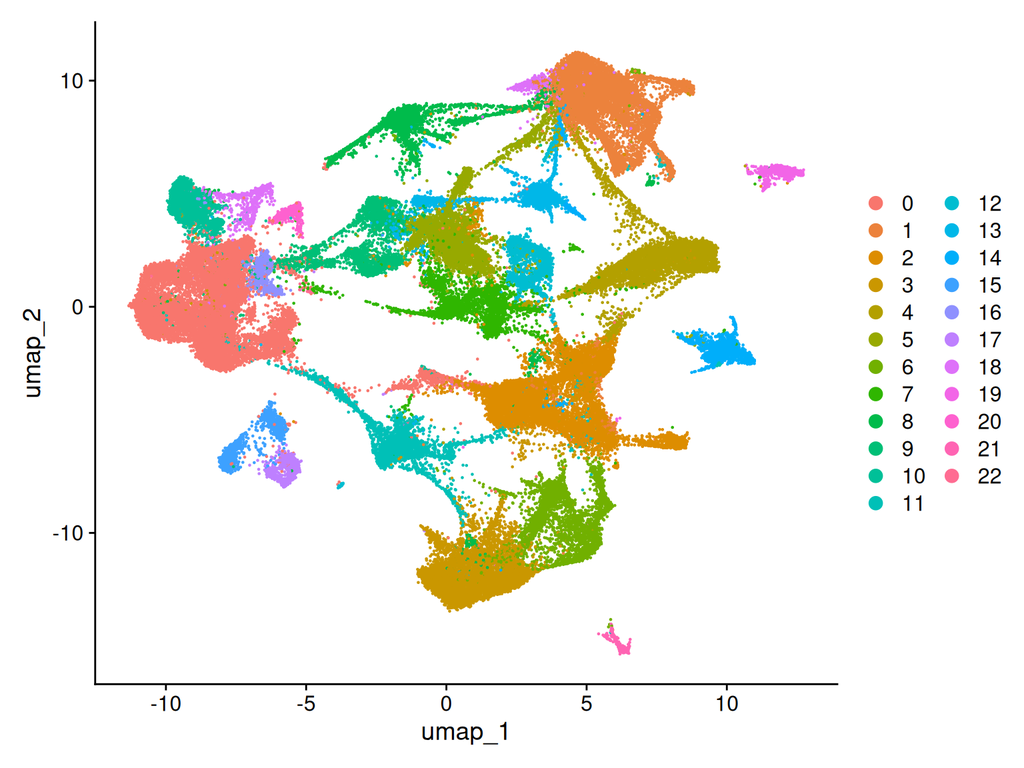

```r
DimPlot(vizgen.obj, reduction = "umap")
```

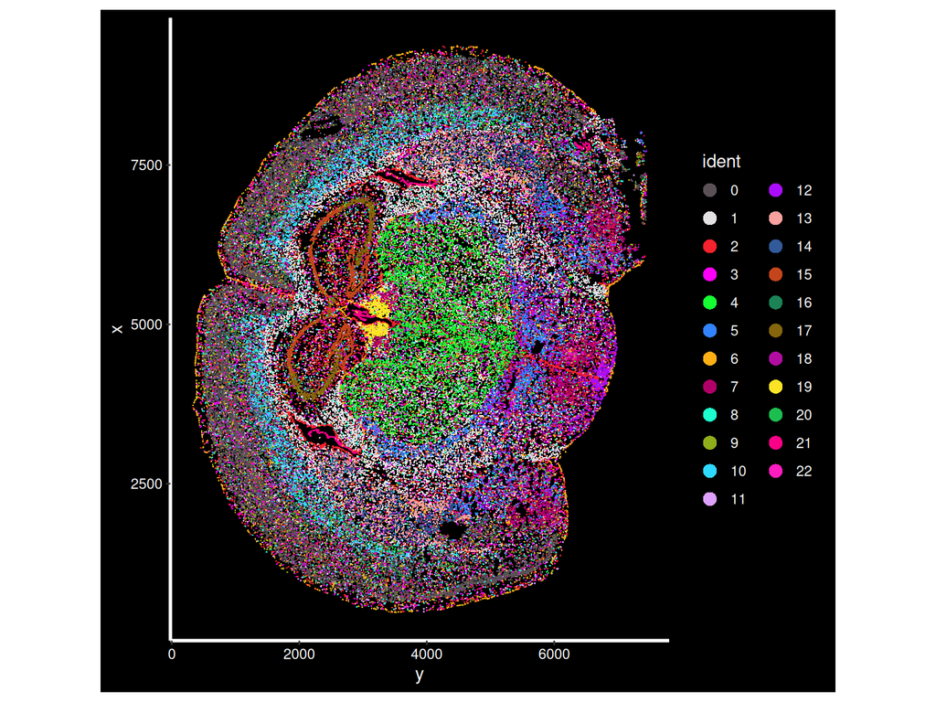

```r
ImageDimPlot(vizgen.obj, fov = "s2r1", cols = "polychrome", axes = TRUE)
```

`ImageDimPlot()` and `ImageFeaturePlot()` accept several customization parameters: `alpha` (within-cell transparency), `size` (centroid point size), `cols` (internal shading palette, for example `polychrome`, `glasbey`, `Paired`, `Set3`, `parade`), `shuffle.cols`, `border.size`, `border.color`, `dark.background`, and `axes`.

Highlight the cells of a single cluster:

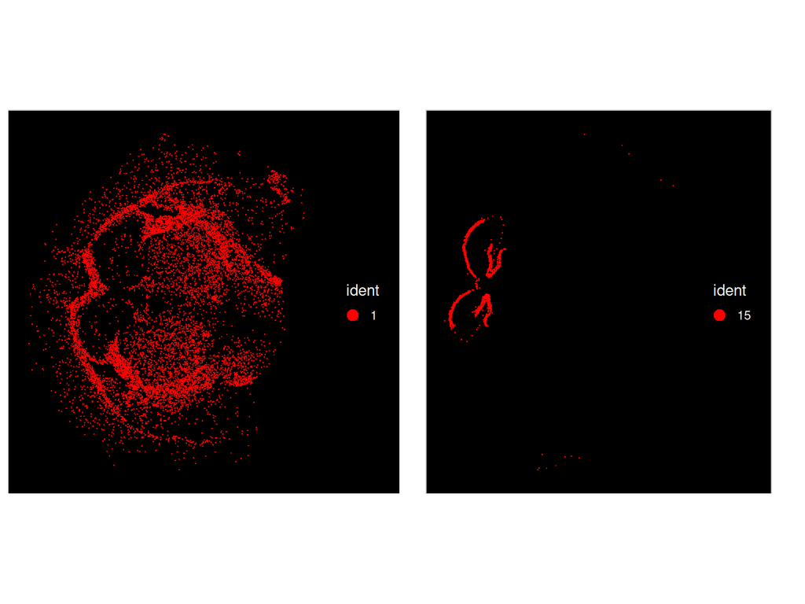

```r
p1 <- ImageDimPlot(vizgen.obj, fov = "s2r1", cols = "red", cells = WhichCells(vizgen.obj, idents = 1))
p2 <- ImageDimPlot(vizgen.obj, fov = "s2r1", cols = "red", cells = WhichCells(vizgen.obj, idents = 15))
p1 + p2
```

Color cells by the quantified expression of a gene with `ImageFeaturePlot()`, and, because MERFISH images individual molecules, show molecule locations too.

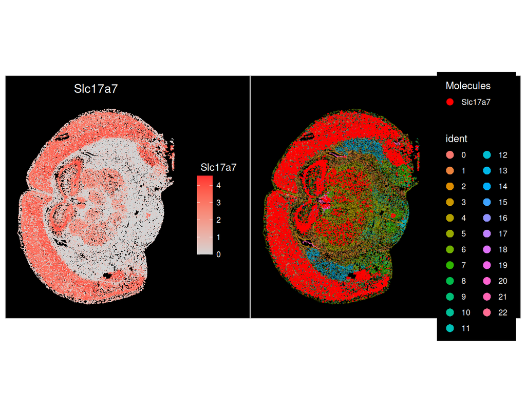

```r
p1 <- ImageFeaturePlot(vizgen.obj, features = "Slc17a7")
p2 <- ImageDimPlot(vizgen.obj, molecules = "Slc17a7", nmols = 10000, alpha = 0.3, mols.cols = "red")
p1 + p2
```

The `nmols` parameter reduces the number of molecules shown to limit overplotting. `mols.size`, `mols.cols`, and `mols.alpha` further tune the display. Plotting molecules is especially useful for co-visualizing several genes.

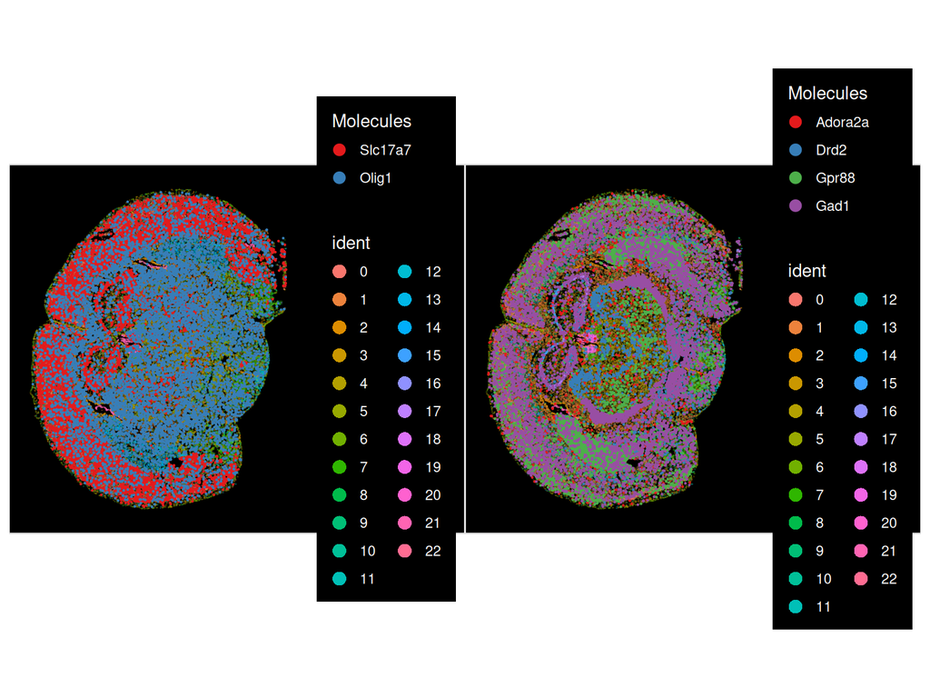

```r
p1 <- ImageDimPlot(vizgen.obj, fov = "s2r1", alpha = 0.3, molecules = c("Slc17a7", "Olig1"), nmols = 10000)
markers.14 <- FindMarkers(vizgen.obj, ident.1 = "14")
p2 <- ImageDimPlot(vizgen.obj, fov = "s2r1", alpha = 0.3, molecules = rownames(markers.14)[1:4],
    nmols = 10000)
p1 + p2
```

By default Seurat treats each cell as a point (a centroid), which speeds up plotting over large areas. We can zoom into a region by creating a new field of view, then switch `DefaultBoundary()` to show full cell segmentations, and optionally `Simplify()` the polygons to speed up plotting.

**ImportantThe crop is pre-computed, and why**

`Crop()` on this 83,546-cell FOV overflows R’s pointer protection stack:

```
Error: protect(): protection stack overflow
  1. SeuratObject::Crop(...) -> ... -> sp::SpatialPolygons(...)
```

Measured 2026-07-26 with sp 2.2.3 and SeuratObject 5.4.0. It does not depend on how much the crop keeps: windows holding 2997, 1729, and 832 cells all fail, as do simplify-then-crop, subset-then-crop, and cropping with centroids as the default boundary. The only fix is starting R with `--max-ppsize=500000`, which is a startup flag, and students reach R through OnDemand RStudio, which starts `rsession` for them with no way to pass it.

So the crop and the `Simplify()` are done once at staging time by `slides/wed_afternoon/staging/stage_vizgen_hippo_fov.R`, and this document reads the result. The chunk below shows the upstream code, unrun, for reference.

```r
# create a Crop
cropped.coords <- Crop(vizgen.obj[["s2r1"]], x = c(1750, 3000), y = c(3750, 5250), coords = "plot")
cropped.coords[["simplified.segmentations"]] <- Simplify(
  coords = cropped.coords[["segmentation"]], tol = 3
)
```

```r
# The staged FOV is the result of the chunk above, cropped to
# x 1750-3000, y 3750-5250, with segmentations simplified at tol = 3.
vizgen.obj[["hippo"]] <- readRDS(
  file.path(data_dir, "vizgen_mouse_brain_s2r1_hippo_fov.rds")
)
```

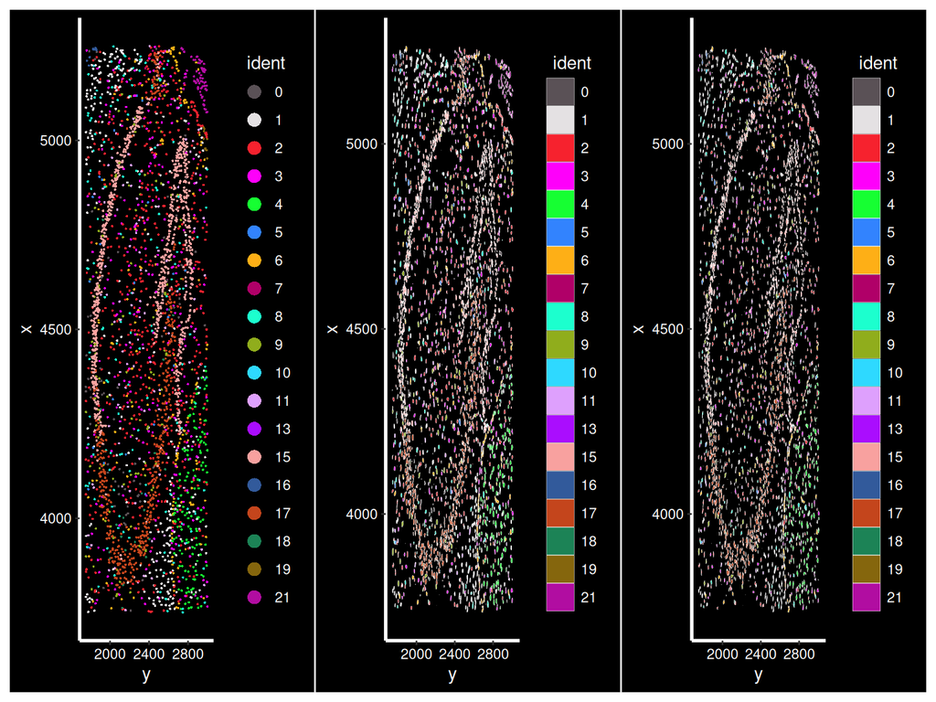

```r
# visualize FOV using default settings (no cell boundaries)
p1 <- ImageDimPlot(vizgen.obj, fov = "hippo", axes = TRUE, size = 0.7, border.color = "white", cols = "polychrome",
    coord.fixed = FALSE)

# visualize FOV with full cell segmentations
DefaultBoundary(vizgen.obj[["hippo"]]) <- "segmentation"
p2 <- ImageDimPlot(vizgen.obj, fov = "hippo", axes = TRUE, border.color = "white", border.size = 0.1,
    cols = "polychrome", coord.fixed = FALSE)

# The simplified segmentations came with the staged FOV, computed at tol = 3,
# so there is nothing to recompute here. Just switch to that boundary.
DefaultBoundary(vizgen.obj[["hippo"]]) <- "simplified.segmentations"
p3 <- ImageDimPlot(vizgen.obj, fov = "hippo", axes = TRUE, border.color = "white", border.size = 0.1,
    cols = "polychrome", coord.fixed = FALSE)

p1 + p2 + p3
```

The `tol` parameter controls how aggressively segmentations are simplified. A higher `tol` drops more vertices, speeding up plotting at the cost of some detail.

Visualize individual molecules at higher resolution after zooming in:

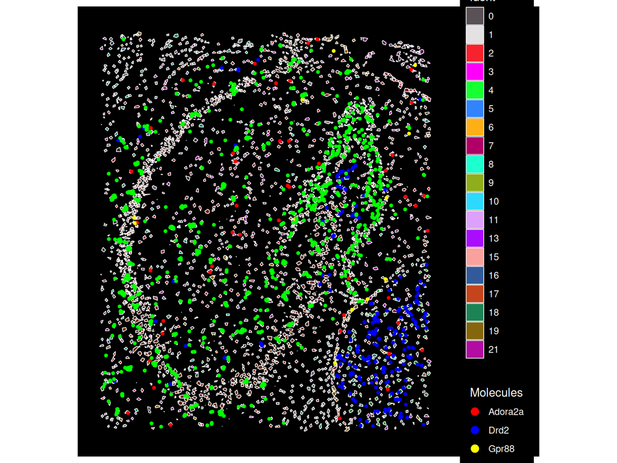

```r
# Since there is nothing behind the segmentations, alpha will slightly mute colors
ImageDimPlot(vizgen.obj, fov = "hippo", molecules = rownames(markers.14)[1:4], cols = "polychrome",
    mols.size = 1, alpha = 0.5, mols.cols = c("red", "blue", "yellow", "green"))
```

```r
# The Vizgen section is done and nothing below refers to these. Each platform
# section here loads a multi-GB object, so without this the session ends up
# holding all three at once. See the memory callout at the top of the document.
rm(list = intersect(c("vizgen.obj", "cropped.coords", "markers.14"), ls()))
invisible(gc())
```

## Mouse Brain: 10x Genomics Xenium In Situ

This section analyzes data from the Xenium platform. `LoadXenium()` reads the per-transcript molecule locations, the cell-by-gene matrix, cell segmentations, and centroids. The RNA data is stored in the `Xenium` assay.

Upstream downloads the “Tiny subset” from the 10x Genomics [Fresh Frozen Mouse Brain for Xenium Explorer Demo](https://www.10xgenomics.com/products/xenium-in-situ/preview-dataset-human-breast) with:

```bash
wget https://cf.10xgenomics.com/samples/xenium/1.0.2/Xenium_V1_FF_Mouse_Brain_Coronal_Subset_CTX_HP/Xenium_V1_FF_Mouse_Brain_Coronal_Subset_CTX_HP_outs.zip
unzip Xenium_V1_FF_Mouse_Brain_Coronal_Subset_CTX_HP_outs.zip
```

**NoteExpected staged layout: Xenium**

`LoadXenium()` wants the **unzipped Xenium output directory**, staged at `spatial_imaging/xenium_tiny_subset/`. That directory holds the standard Xenium `outs`: `cell_feature_matrix.h5` (or the `cell_feature_matrix/` MTX directory), `cells.csv.gz`, `cell_boundaries.csv.gz`, `transcripts.csv.gz` (or their `.parquet` equivalents), and `experiment.xenium`. Upstream original path was `/brahms/hartmana/vignette_data/xenium_tiny_subset`. Installing `arrow` and `hdf5r` speeds up loading.

```r
path <- file.path(data_dir, "xenium_tiny_subset")
# Load the Xenium data
xenium.obj <- LoadXenium(path, fov = "fov", segmentations = "cell")
# remove cells with 0 counts
xenium.obj <- subset(xenium.obj, subset = nCount_Xenium > 0)
```

Standard QC violin plots via the `Xenium` assay:

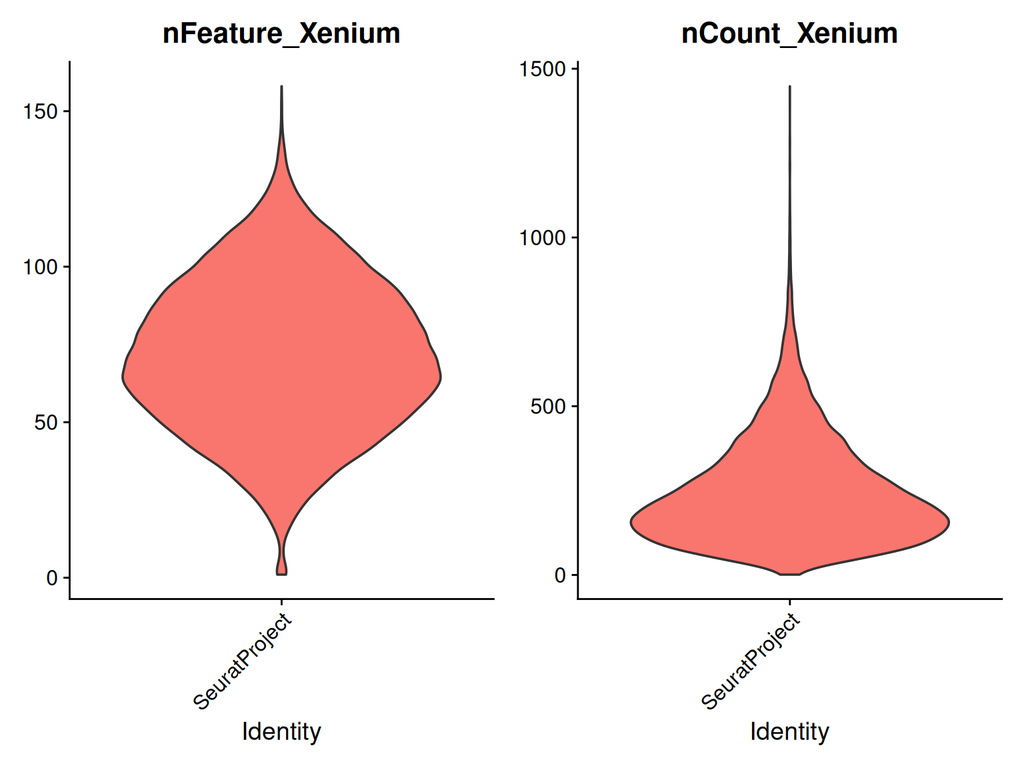

```r
VlnPlot(xenium.obj, features = c("nFeature_Xenium", "nCount_Xenium"), ncol = 2, pt.size = 0)
```

Plot molecule positions of marker genes with `ImageDimPlot()`:

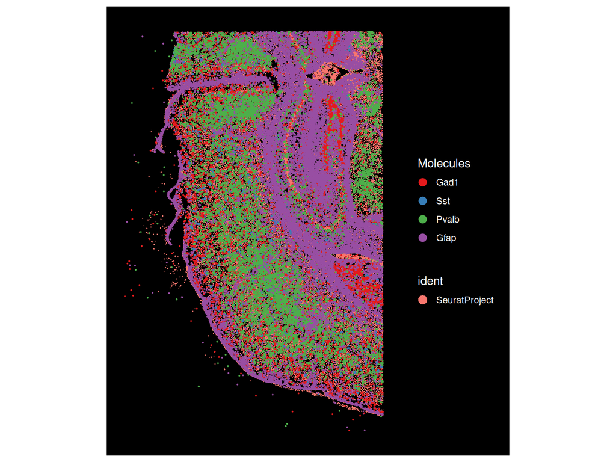

```r
ImageDimPlot(xenium.obj, fov = "fov", molecules = c("Gad1", "Sst", "Pvalb", "Gfap"), nmols = 20000)
```

Per-cell expression of layer markers, with `max.cutoff` set roughly to each gene’s 90th percentile to improve contrast:

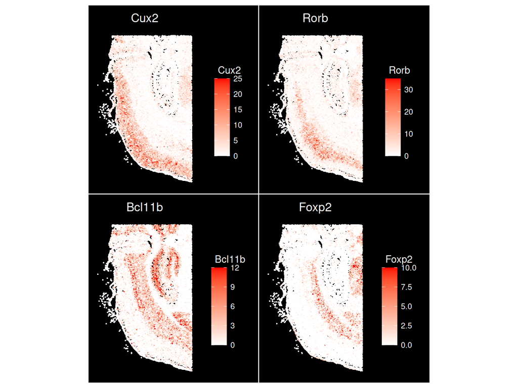

```r
ImageFeaturePlot(xenium.obj, features = c("Cux2", "Rorb", "Bcl11b", "Foxp2"), max.cutoff = c(25,
    35, 12, 10), size = 0.75, cols = c("white", "red"))
```

Zoom in with `Crop()`, then show segmentations plus molecules:

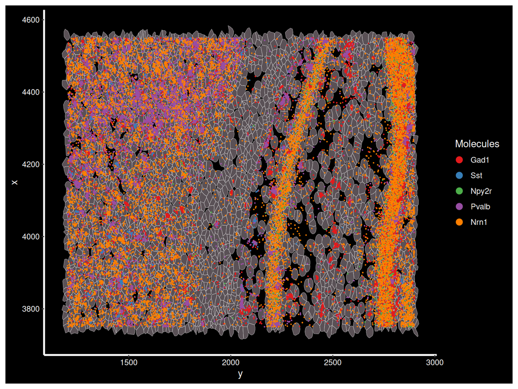

```r
cropped.coords <- Crop(xenium.obj[["fov"]], x = c(1200, 2900), y = c(3750, 4550), coords = "plot")
xenium.obj[["zoom"]] <- cropped.coords
# visualize cropped area with cell segmentations & selected molecules
DefaultBoundary(xenium.obj[["zoom"]]) <- "segmentation"
ImageDimPlot(xenium.obj, fov = "zoom", axes = TRUE, border.color = "white", border.size = 0.1, cols = "polychrome",
    coord.fixed = FALSE, molecules = c("Gad1", "Sst", "Npy2r", "Pvalb", "Nrn1"), nmols = 10000)
```

SCTransform normalization, dimensional reduction, and clustering:

```r
xenium.obj <- without_workers(SCTransform(xenium.obj, assay = "Xenium"))
xenium.obj <- RunPCA(xenium.obj, npcs = 30, features = rownames(xenium.obj))
xenium.obj <- RunUMAP(xenium.obj, dims = 1:30)
xenium.obj <- FindNeighbors(xenium.obj, reduction = "pca", dims = 1:30)
xenium.obj <- FindClusters(xenium.obj, resolution = 0.3)
```

```
Modularity Optimizer version 1.3.0 by Ludo Waltman and Nees Jan van Eck

Number of nodes: 36553
Number of edges: 1341087

Running Louvain algorithm...
Maximum modularity in 10 random starts: 0.9582
Number of communities: 27
Elapsed time: 10 seconds
```

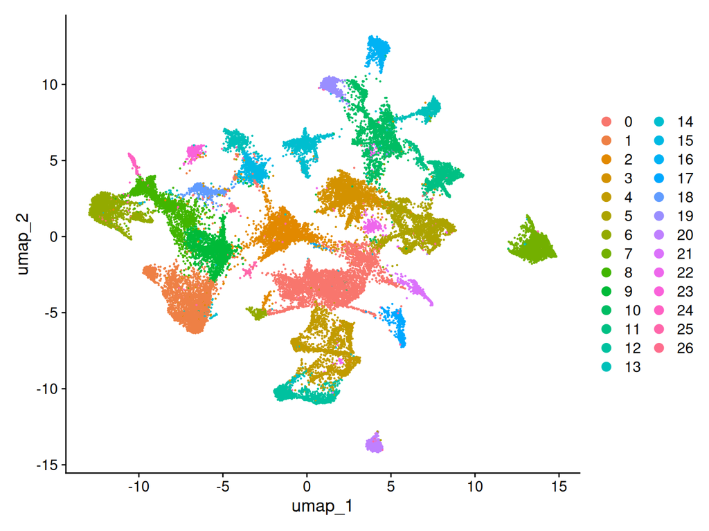

```r
DimPlot(xenium.obj)
```

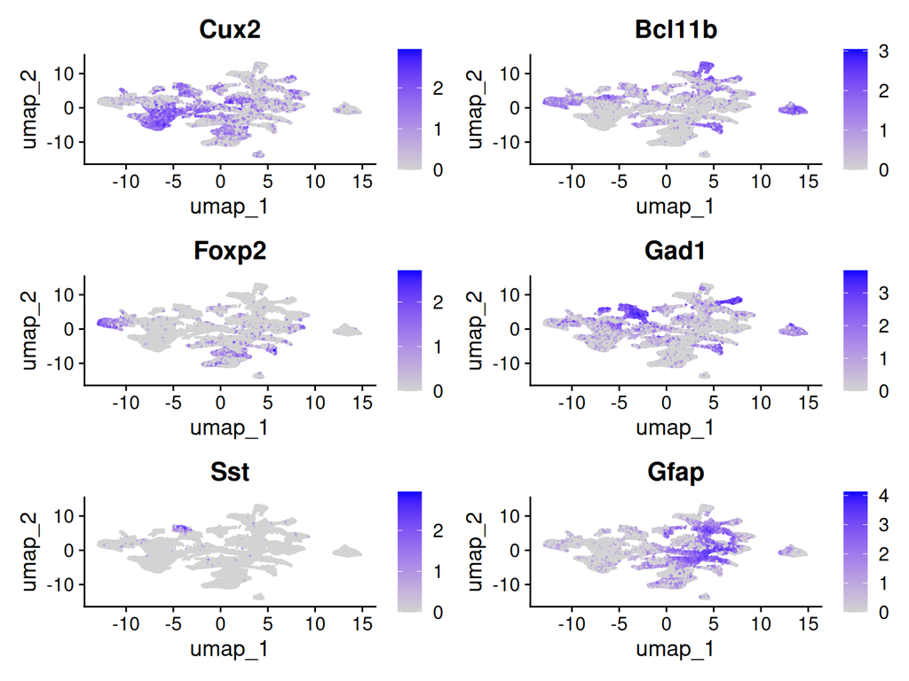

```r
FeaturePlot(xenium.obj, features = c("Cux2", "Bcl11b", "Foxp2", "Gad1", "Sst", "Gfap"))
```

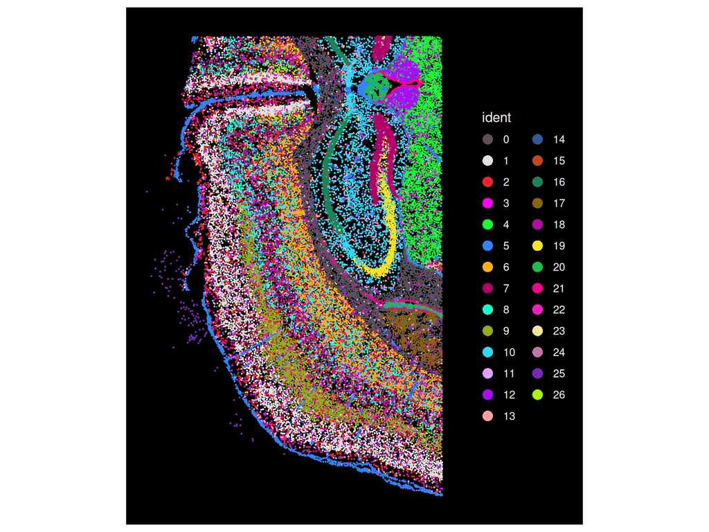

```r
ImageDimPlot(xenium.obj, cols = "polychrome", size = 0.75)
```

### Spatial niches with RCTD annotation

Using each cell’s position we compute spatial niches. We use a cortex reference from the Allen Brain Institute to annotate cells, cropping the dataset to the cortex first. Below, `Slc17a7` expression helps locate the cortical region.

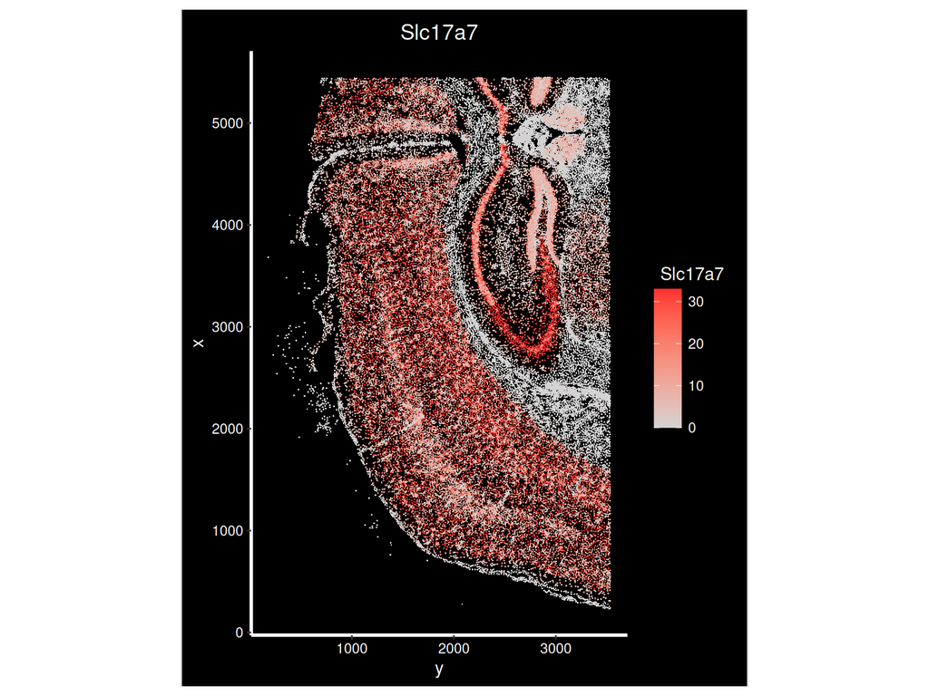

```r
xenium.obj <- LoadXenium(file.path(data_dir, "xenium_tiny_subset"))
p1 <- ImageFeaturePlot(xenium.obj, features = "Slc17a7", axes = TRUE, max.cutoff = "q90")
p1
```

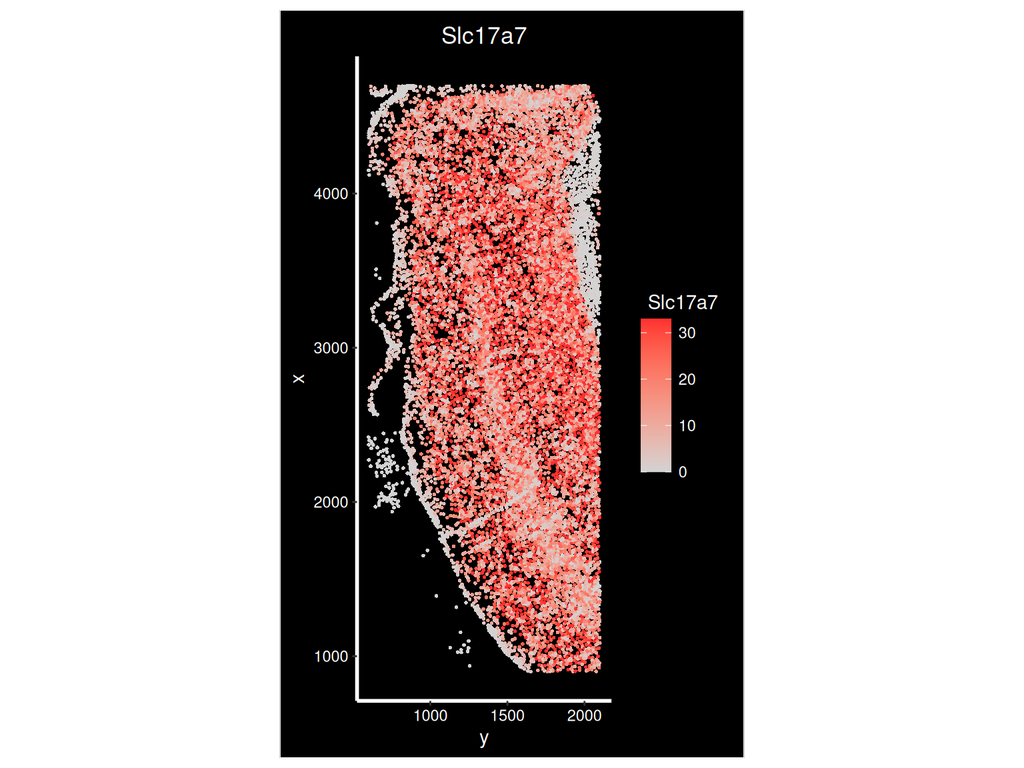

```r
crop <- Crop(xenium.obj[["fov"]], x = c(600, 2100), y = c(900, 4700))
xenium.obj[["crop"]] <- crop
p2 <- ImageFeaturePlot(xenium.obj, fov = "crop", features = "Slc17a7", size = 1, axes = TRUE, max.cutoff = "q90")
p2
```

Seurat v5 supports Robust Cell Type Decomposition (RCTD) to deconvolve spatial data using an scRNA-seq reference. RCTD is implemented in the `spacexr` package, which comes from GitHub rather than CRAN (https://github.com/dmcable/spacexr).

`spacexr` must already be installed on the machine running this tutorial. Installing it here would mean a network call during the session, so this document only checks for it.

```r
if (!requireNamespace("spacexr", quietly = TRUE)) {
  stop(
    "spacexr is not installed. Install it before the workshop, it is not ",
    "installed during a session."
  )
}
```

**NoteExpected staged file: Allen cortex reference**

The RCTD reference is a single `.rds`, staged once at the top level of the workshop data dir as `allen_cortex.rds` (shared with the Visium tutorial). Upstream downloads it from https://www.dropbox.com/s/cuowvm4vrf65pvq/allen_cortex.rds?dl=1 and read it from `/brahms/shared/vignette-data/allen_cortex.rds`. This one is a plain Seurat scRNA-seq object, so a staged `.rds` is the natural format (no directory of raw files needed).

```r
library(spacexr)

query.counts <- GetAssayData(xenium.obj, assay = "Xenium", layer = "counts")[, Cells(xenium.obj[["crop"]])]
coords <- GetTissueCoordinates(xenium.obj[["crop"]], which = "centroids")
rownames(coords) <- coords$cell
coords$cell <- NULL
query <- SpatialRNA(coords, query.counts, colSums(query.counts))
# allen.cortex.ref can be downloaded from:
# https://www.dropbox.com/s/cuowvm4vrf65pvq/allen_cortex.rds?dl=1
allen.cortex.ref <- readRDS(file.path(data_root, "allen_cortex.rds"))
allen.cortex.ref <- UpdateSeuratObject(allen.cortex.ref)

Idents(allen.cortex.ref) <- "subclass"
# remove CR cells because there aren't enough of them for annotation
allen.cortex.ref <- subset(allen.cortex.ref, subset = subclass != "CR")
counts <- GetAssayData(allen.cortex.ref, assay = "RNA", layer = "counts")
cluster <- as.factor(allen.cortex.ref$subclass)
names(cluster) <- colnames(allen.cortex.ref)
nUMI <- allen.cortex.ref$nCount_RNA
names(nUMI) <- colnames(allen.cortex.ref)
nUMI <- colSums(counts)
levels(cluster) <- gsub("/", "-", levels(cluster))
reference <- Reference(counts, cluster, nUMI)
# max_cores = 2, not 8. Each RCTD worker is a separate R process holding its own
# copy of the reference. Measured 2026-07-27: max_cores = 8 spawned eight
# workers at ~165% CPU each, saturating all 16 threads, filling 30 GB, and
# pushing 24 GB into swap. Students have 16 GB and fewer cores. The same cap is
# applied in spatial_vignette_local.qmd for the same reason.
RCTD <- create.RCTD(query, reference, max_cores = 2)
```

```
     Astro       Endo    L2-3 IT         L4      L5 IT      L5 PT      L6 CT
       368         94        982       1401        880        544        960
     L6 IT        L6b      Lamp5 Macrophage      Meis2         NP      Oligo
      1872        358       1122         51         45        362         91
      Peri      Pvalb   Serpinf1        SMC       Sncg        Sst        Vip
        32       1337         27         55        125       1741       1728
      VLMC
        67
```

```r
RCTD <- run.RCTD(RCTD, doublet_mode = "doublet")
```

```
[1] "gather_results: finished 1000"
[1] "gather_results: finished 2000"
[1] "gather_results: finished 3000"
[1] "gather_results: finished 4000"
[1] "gather_results: finished 5000"
[1] "gather_results: finished 6000"
[1] "gather_results: finished 7000"
[1] "gather_results: finished 8000"
[1] "gather_results: finished 9000"
[1] "gather_results: finished 10000"
```

```r
annotations.df <- RCTD@results$results_df
annotations <- annotations.df$first_type
names(annotations) <- rownames(annotations.df)
xenium.obj$predicted.celltype <- annotations
keep.cells <- Cells(xenium.obj)[!is.na(xenium.obj$predicted.celltype)]
xenium.obj <- subset(xenium.obj, cells = keep.cells)
```

Seurat v5 introduces niche analysis, which groups cells by the composition of their local spatial neighborhood. `BuildNicheAssay()` builds a `niche` assay of neighboring cell-type composition and returns a `niches` metadata column of k-means cluster assignments.

```r
xenium.obj <- BuildNicheAssay(object = xenium.obj, fov = "crop", group.by = "predicted.celltype",
    niches.k = 5, neighbors.k = 30)
```

Group cells by cell-type identity or by niche identity:

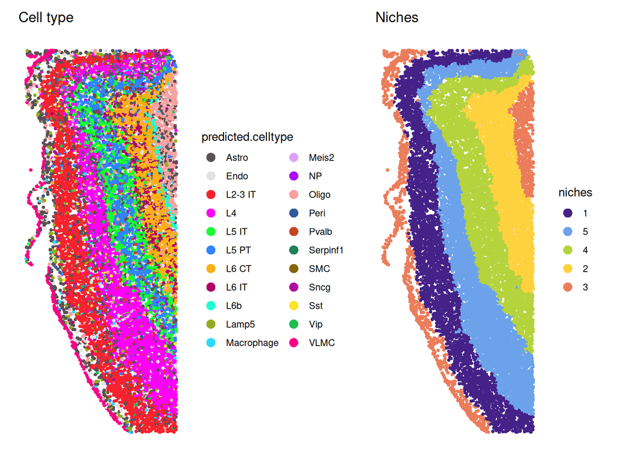

```r
celltype.plot <- ImageDimPlot(xenium.obj, group.by = "predicted.celltype", size = 1.5, cols = "polychrome",
    dark.background = F) + ggtitle("Cell type")
niche.plot <- ImageDimPlot(xenium.obj, group.by = "niches", size = 1.5, dark.background = F) + ggtitle("Niches") +
    scale_fill_manual(values = c("#442288", "#6CA2EA", "#B5D33D", "#FED23F", "#EB7D5B"))
celltype.plot | niche.plot
```

Each niche is enriched for distinct cell types:

```r
table(xenium.obj$predicted.celltype, xenium.obj$niches)
```

```
                1    2    3    4    5
  Astro       275  133  315  159  303
  Endo        106   66   83   78  195
  L2-3 IT    1623    5    8    1  122
  L4          135    6    4   71 1949
  L5 IT         1   75    1  694   79
  L5 PT        38   21    6  742   47
  L6 CT         1  918    0   46    1
  L6 IT         8  262    3   37   13
  L6b           0   97    3    0    0
  Lamp5        64   10   61   10   22
  Macrophage   26   10   21   22   33
  Meis2         0    0    0    0    1
  NP            0    6    0   79    1
  Oligo        53  131  278   75   79
  Peri         15   11    7   10   25
  Pvalb        49   48    3   69   97
  Serpinf1      5    1    0    1    4
  SMC           0    0    0    1    3
  Sncg         24    7    2    1    1
  Sst          17   20    0   42   31
  Vip          16    3    6    8   25
  VLMC          7    3  262    6   28
```

```r
# Same again: the Xenium section and its RCTD deconvolution are done. The RCTD
# reference and query are the largest items here.
rm(list = intersect(
  c("xenium.obj", "crop", "cropped.coords", "query", "reference", "RCTD",
    "allen.cortex.ref", "counts", "cluster", "nUMI", "annotations"),
  ls()
))
invisible(gc())
```

## Human Lung: Nanostring CosMx Spatial Molecular Imager

This dataset comes from the Nanostring CosMx Spatial Molecular Imager (SMI), which does multiplexed single-molecule profiling of RNA and protein and works on FFPE tissue. The full dataset is 8 FFPE samples from 5 non-small-cell lung cancer (NSCLC) tissues, with a 960-transcript panel. Here we load one sample, lung 5 replicate 1.

`LoadNanostring()` parses the public download outputs. Instead of unsupervised analysis, this section maps the profiles onto a precomputed Azimuth Healthy Human Lung reference (Azimuth 0.4.3, human lung reference 1.0.0). The median detected transcripts per cell is 249.

**NoteExpected staged layout: Nanostring CosMx**

`LoadNanostring()` wants a **directory** of CosMx outputs, staged at `spatial_imaging/nanostring_lung5_rep1/`. It matches four files by pattern, and all four must be in that one directory:

| Pattern | File here |
| --- | --- |
| `*_exprMat_file.csv` | `Lung5_Rep1_exprMat_file.csv`, 198 MB |
| `*_metadata_file.csv` | `Lung5_Rep1_metadata_file.csv`, 11.5 MB |
| `*_tx_file.csv` | `Lung5_Rep1_tx_file.csv`, 3.40 GB |
| `*-polygons.csv` | `Lung5_Rep1-polygons.csv`, 120 MB |

The first three come from the vendor download, which needs registration. The cell boundary polygons come from elsewhere, a public Dropbox link, and are also staged one level up at `spatial_imaging/Lung5_Rep1-polygons.csv` for convenience. The copy inside the directory is a hard link to that one, because `ReadNanostring()` will only look in `data.dir`. `..._fov_positions_file.csv` ships with the download but is not one of the four the loader reads.

Upstream original path was `/brahms/hartmana/vignette_data/nanostring/lung5_rep1`.

The precomputed Azimuth annotations are a single `.Rds` staged at `spatial_imaging/nanostring_data.Rds` (a list with `$annotations` and `$umap`). Upstream original path was `/brahms/hartmana/vignette_data/nanostring_data.Rds`, downloadable from the Seurat vignette data site.

**ImportantThe Nanostring load is pre-computed, for the same reason as the Vizgen crop**

`LoadNanostring()` builds an `sp::SpatialPolygons` object from the cell segmentations and overflows R’s pointer protection stack, exactly as `Crop()` does earlier in this document:

```
Error: protect(): protection stack overflow
  1. Seurat::LoadNanostring(...)
  2. SeuratObject::CreateSegmentation(data$segmentations)
  4. sp::SpatialPolygons(Srl = coords)
```

Measured 2026-07-26 with sp 2.2.3 and SeuratObject 5.4.0. The fix is `--max-ppsize=500000`, a startup flag students cannot set in OnDemand RStudio, so the load is done once by `slides/wed_afternoon/staging/stage_nanostring_object.R` and this document reads the result. The Azimuth annotations and the `SCTransform()` below still run here, they are part of the lesson and they are cheap.

```r
# The upstream call, shown but not run. This is what produced the staged object.
nano.obj <- LoadNanostring(data.dir = file.path(data_dir, "nanostring_lung5_rep1"), fov = "lung5.rep1")
```

```r
nano.obj <- readRDS(file.path(data_dir, "nanostring_lung5_rep1.rds"))
# add in precomputed Azimuth annotations
azimuth.data <- readRDS(file.path(data_dir, "nanostring_data.Rds"))
nano.obj <- AddMetaData(nano.obj, metadata = azimuth.data$annotations)
nano.obj[["proj.umap"]] <- azimuth.data$umap
Idents(nano.obj) <- nano.obj$predicted.annotation.l1

nano.obj <- without_workers(
  SCTransform(nano.obj, assay = "Nanostring", clip.range = c(-10, 10), verbose = FALSE)
)

# text display of annotations and prediction scores
head(slot(object = nano.obj, name = "meta.data")[2:5])
```

```
    nCount_Nanostring nFeature_Nanostring predicted.annotation.l1
1_1                23                  19               Dendritic
2_1                26                  23              Macrophage
3_1                74                  51          Neuroendocrine
4_1                60                  48              Macrophage
5_1                52                  39              Macrophage
6_1                 5                   5                   CD4 T
    predicted.annotation.l1.score
1_1                     0.5884506
2_1                     0.5707920
3_1                     0.5449661
4_1                     0.6951970
5_1                     0.8155319
6_1                     0.5677324
```

Cells projected onto the reference-defined UMAP. For this NSCLC sample the tumor cells are annotated as “basal”, the closest cell type in the healthy reference.

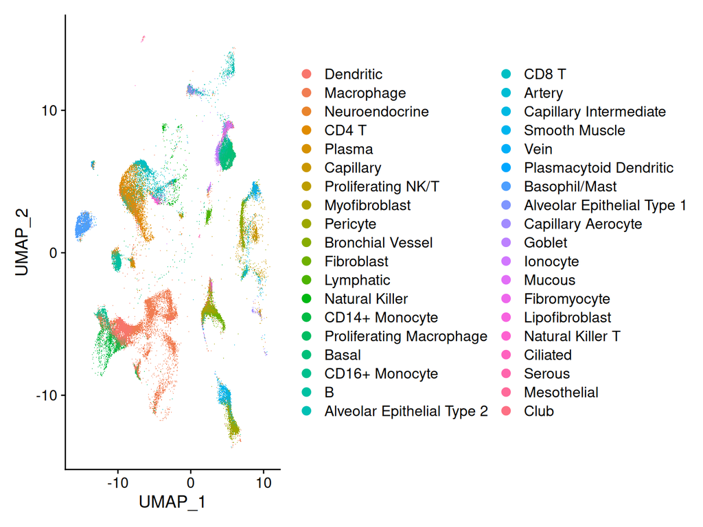

```r
DimPlot(nano.obj)
```

### Visualization of cell type and expression localization patterns

`ImageDimPlot()` plots cells by spatial location, colored by assigned cell type. The basal (tumor) population is tightly spatially organized.

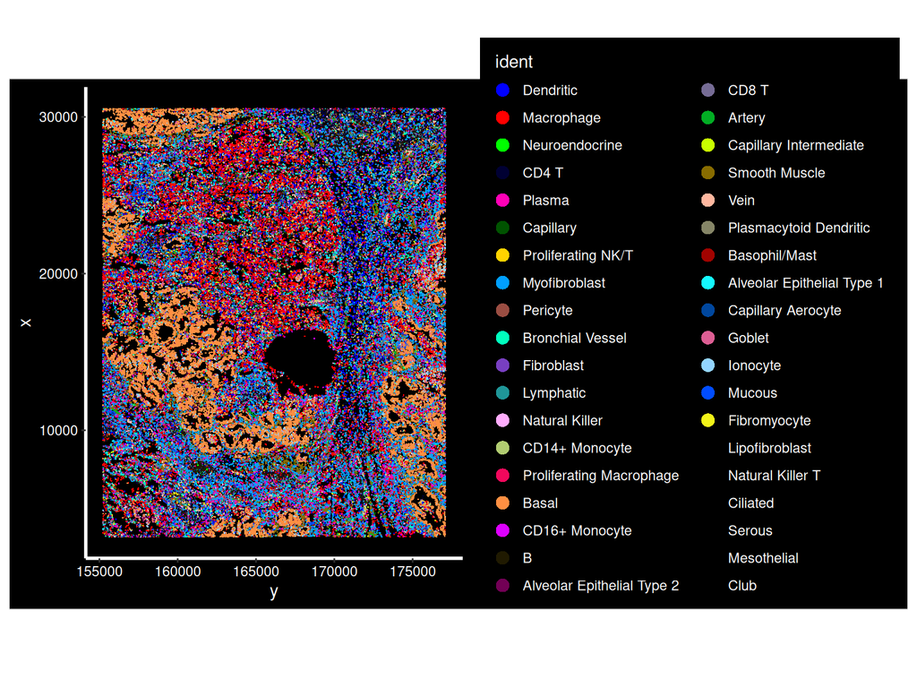

```r
ImageDimPlot(nano.obj, fov = "lung5.rep1", axes = TRUE, cols = "glasbey")
```

Highlight a few cell-type groups:

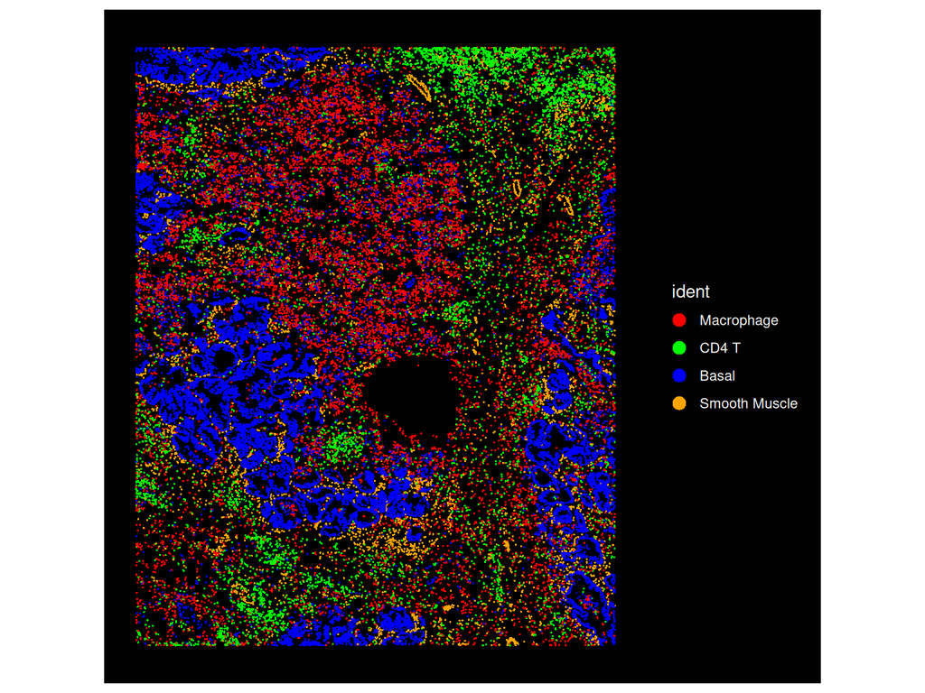

```r
ImageDimPlot(nano.obj, fov = "lung5.rep1", cells = WhichCells(nano.obj, idents = c("Basal", "Macrophage",
    "Smooth Muscle", "CD4 T")), cols = c("red", "green", "blue", "orange"), size = 0.6)
```

Visualize the marker `KRT17` several ways:

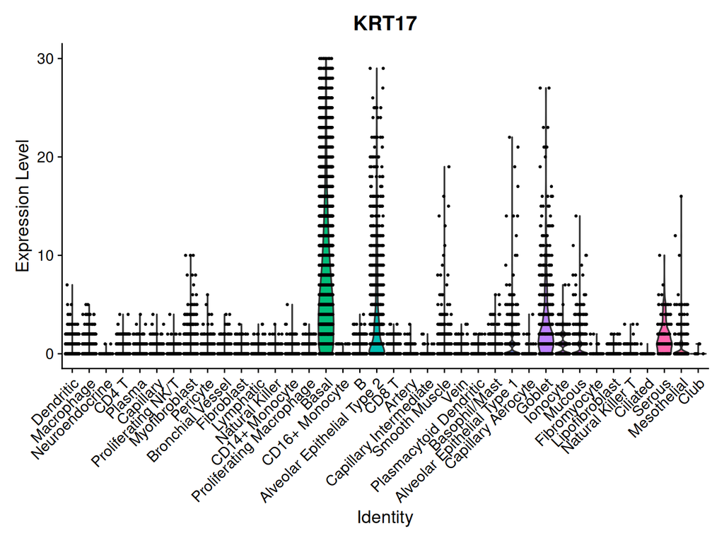

```r
VlnPlot(nano.obj, features = "KRT17", assay = "Nanostring", layer = "counts", pt.size = 0.1, y.max = 30) +
    NoLegend()
```

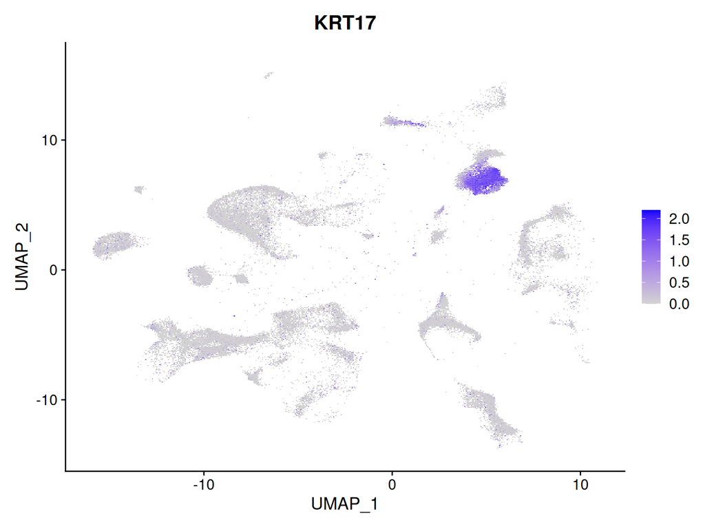

```r
FeaturePlot(nano.obj, features = "KRT17", max.cutoff = "q95")
```

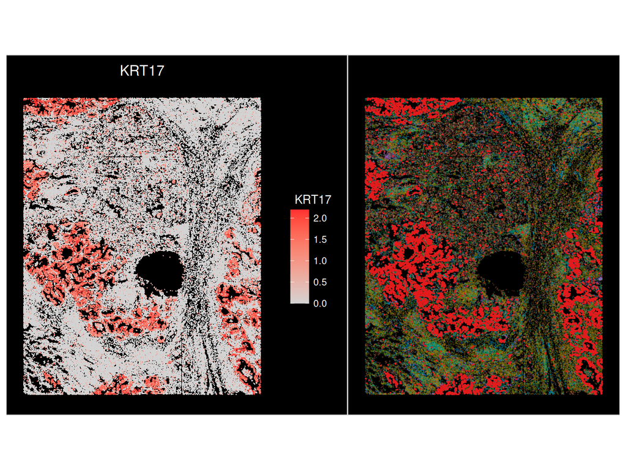

```r
p1 <- ImageFeaturePlot(nano.obj, fov = "lung5.rep1", features = "KRT17", max.cutoff = "q95")
p2 <- ImageDimPlot(nano.obj, fov = "lung5.rep1", alpha = 0.3, molecules = "KRT17", nmols = 10000) +
    NoLegend()
p1 + p2
```

Co-visualize several markers: `KRT17` (basal cells), `C1QA` (macrophages), `IL7R` (T cells), `TAGLN` (smooth muscle).

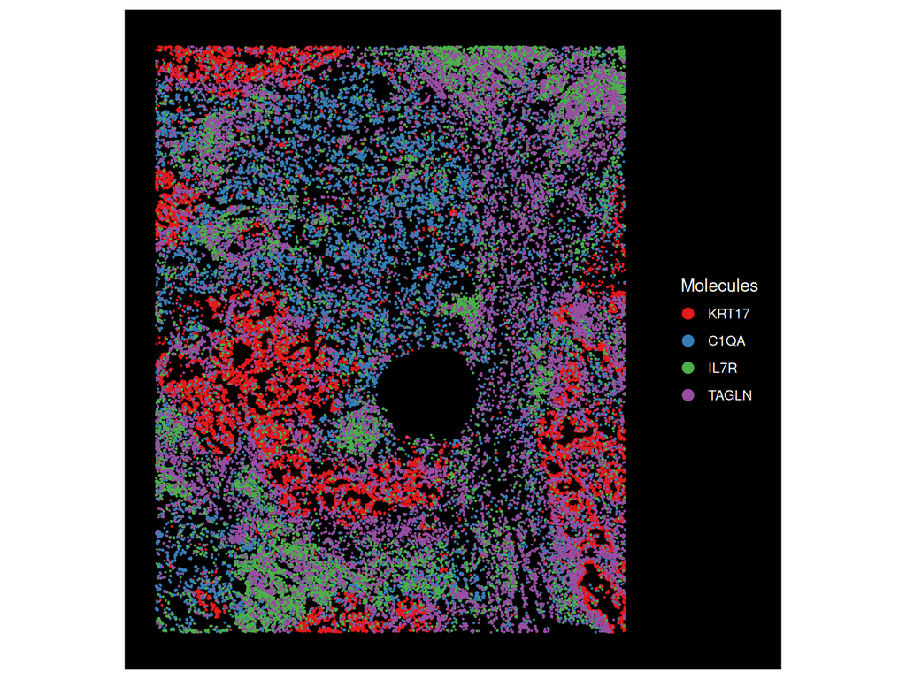

```r
# Plot some of the molecules which seem to display spatial correlation with each other
ImageDimPlot(nano.obj, fov = "lung5.rep1", group.by = NA, alpha = 0.3, molecules = c("KRT17", "C1QA",
    "IL7R", "TAGLN"), nmols = 20000)
```

Zoom in on a basal-rich region and show cell boundaries:

This crop is staged too, for the same protection-stack reason as the load. The upstream call is shown but not run.

```r
basal.crop <- Crop(nano.obj[["lung5.rep1"]], x = c(159500, 164000), y = c(8700, 10500))
DefaultBoundary(basal.crop) <- "segmentation"
```

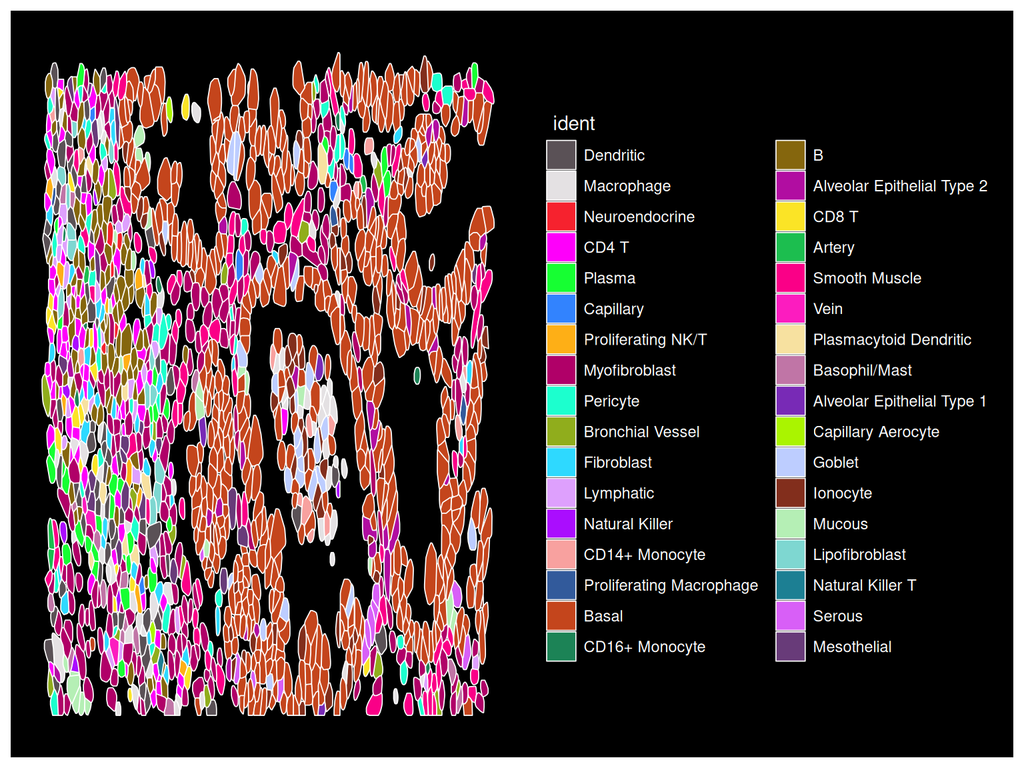

```r
nano.obj[["zoom1"]] <- readRDS(
  file.path(data_dir, "nanostring_lung5_rep1_zoom1_fov.rds")
)
ImageDimPlot(nano.obj, fov = "zoom1", cols = "polychrome", coord.fixed = FALSE)
```

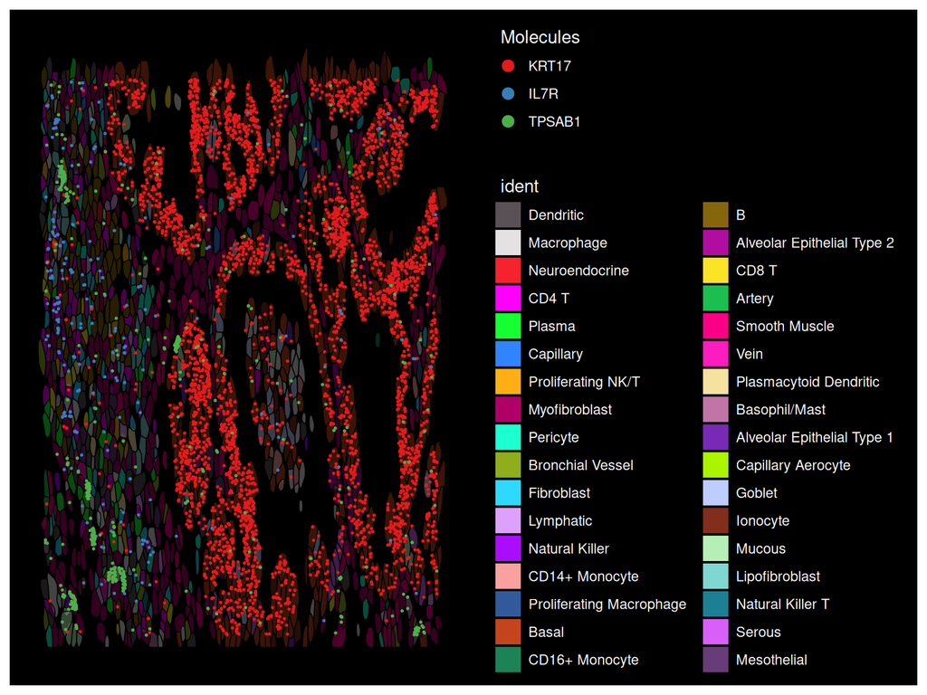

```r
# note the clouds of TPSAB1 molecules denoting mast cells
ImageDimPlot(nano.obj, fov = "zoom1", cols = "polychrome", alpha = 0.3, molecules = c("KRT17", "IL7R",
    "TPSAB1"), mols.size = 0.3, nmols = 20000, border.color = "black", coord.fixed = FALSE)
```